# PSCI 3200 Final Project Assignment 3 Draft

Author

Affiliation

Zach Koung

University of Pennsylvania

## **Task 1: Introduction**

*Afghanistan. Algeria. Bangladesh. Brunei. Burundi. Cameroon. Chad. Comoros. Dominica. Egypt. Eritrea. Eswatini. Ethiopia. Gambia. Ghana. Grenada. Guinea. Guyana. Iran. Jamaica. Kenya. Kiribati. Kuwait. Lebanon. Liberia. Libya. Malawi. Malaysia. Maldives. Mauritania. Morocco. Myanmar. Namibia. Nigeria. Occupied Palestinian Territory (Gaza Strip). Oman. Pakistan. Papua New Guinea. Qatar. Saint Lucia. Saint Vincent and The Grenadines. Samoa. Saudi Arabia. Senegal. Sierra Leone. Solomon Islands. Somalia. South Sudan. Sri Lanka. Sudan. Syria. Tanzania. Togo. Tonga. Tunisia. Turkmenistan. Tuvalu. Uganda. United Arab Emirates. Uzbekistan. Yemen. Zambia. Zimbabwe.*

## Task 2: Data

**Data Souces**

In this research, I am employing two different data sources. In order to asses the dependent/outcome variable, tourism volume, I am utilizing the World Bank’s [**International tourism, number of arrivals**](https://data.worldbank.org/indicator/ST.INT.ARVL)measures. The downloadable data set has data at the country and year level. For example, it has the number of tourist arrivals to the United States in 2014. Note that the data is not perfect, there is some missing data for specific countries and years.

The second datset is the from the Spartacus Gay Travel Guide which pubishes yearly reports on each country and variety of different metrics, from whether or not Pride festivals and parades are banned in a given country and year to whether there is HIV-related travel restrictions.

While the data was relatively complete, I did narrow down the years I would work with. I decided to not use any data starting from Janurary 1, 2020, to remove the issue with COVID-related travel dilemmas. Because the Gay Travel Guide only begins in 2012, the final window is for 2012-2019 and for all countries that existed in both the Gay Travel Guide and the World Bank Travel Data.

**Discussion of key variables**

Dependent Variable

- Tourism volume percent change from the previous year (**tour_pct**):
  - Final unit of analysis is by country and year. Sample is not just countries but also territories (ex: US Virgin Islands), regions (ex: MENA), and other buckets such as income buckets (developing) which I discarded.

Independent Variables

Summary Statistics for CHANGE in All Variables

| Variable | Min | Q1 | Q2 | Mean | Q3 | Q4 | Max |
| --- | --- | --- | --- | --- | --- | --- | --- |
| Tourism Percent Change | -67.3 | 0.7 | 5.1 | 6.5 | 10.5 | 205.9 | 205.9 |
| Total LGBTQ+ Friendliness | -5.0 | 0.0 | 0.0 | 0.2 | 0.0 | 4.0 | 4.0 |
| Adoption allowed | -1.0 | 0.0 | 0.0 | 0.0 | 0.0 | 2.0 | 2.0 |
| Anitdiscrimination | -1.0 | 0.0 | 0.0 | 0.1 | 0.0 | 3.0 | 3.0 |
| Anti-gay laws | -1.0 | 0.0 | 0.0 | 0.0 | 0.0 | 1.0 | 1.0 |
| Death sentences | -5.0 | 0.0 | 0.0 | 0.0 | 0.0 | 4.0 | 4.0 |
| Equal Age of Consent | -1.0 | 0.0 | 0.0 | 0.0 | 0.0 | 1.0 | 1.0 |
| HIV-travel restrictions | -2.0 | 0.0 | 0.0 | 0.0 | 0.0 | 2.0 | 2.0 |
| Homosexuality illegal | -2.0 | 0.0 | 0.0 | 0.0 | 0.0 | 2.0 | 2.0 |
| LGBT-Marketing | -1.0 | 0.0 | 0.0 | 0.0 | 0.0 | 1.0 | 1.0 |
| Locals hostile | -2.0 | 0.0 | 0.0 | 0.0 | 0.0 | 2.0 | 2.0 |
| Marriage / Partnership | -1.0 | 0.0 | 0.0 | 0.0 | 0.0 | 2.0 | 2.0 |
| Murders | -5.0 | 0.0 | 0.0 | 0.0 | 0.0 | 5.0 | 5.0 |
| Pride banned | -2.0 | 0.0 | 0.0 | 0.0 | 0.0 | 2.0 | 2.0 |
| Prosecution | -2.0 | 0.0 | 0.0 | 0.0 | 0.0 | 2.0 | 2.0 |
| Religious influence | -3.0 | 0.0 | 0.0 | 0.0 | 0.0 | 3.0 | 3.0 |

As you can see, because this is looking at the statiscs in the chnage of variables from one year to the next, it does not tell us much on the LGBTQ side of things, this is because most countries simply do not observe changes from one year to the next and such the mean and median tend to be 0. Let me show you a chart and graph of just the LGBTQ variabels, raw score which should just show the distribution of the raw variables!

Summary Statistics for LGBT Variables (Measuring Raw Score for all Years)

| Variable | Min | Q1 | Q2 | Mean | Q3 | Q4 | Max |
| --- | --- | --- | --- | --- | --- | --- | --- |
| Total LGBTQ+ Friendliness | -16 | -5 | -2 | -1.6 | 2 | 10 | 10 |
| Adoption allowed | 0 | 0 | 0 | 0.3 | 0 | 2 | 2 |
| Anitdiscrimination | -1 | 0 | 0 | 0.7 | 1 | 3 | 3 |
| Anti-gay laws | -2 | -1 | 0 | -0.4 | 0 | 0 | 0 |
| Death sentences | -5 | 0 | 0 | -0.1 | 0 | 0 | 0 |
| Equal Age of Consent | -1 | 0 | 1 | 0.6 | 1 | 1 | 1 |
| HIV-travel restrictions | -3 | 0 | 0 | -0.2 | 0 | 0 | 0 |
| Homosexuality illegal | -2 | -1 | 0 | -0.3 | 0 | 0 | 0 |
| LGBT-Marketing | 0 | 0 | 0 | 0.2 | 0 | 1 | 1 |
| Locals hostile | -2 | -2 | -1 | -1.0 | 0 | 0 | 0 |
| Marriage / Partnership | -1 | 0 | 0 | 0.4 | 0 | 2 | 2 |
| Murders | -5 | 0 | 0 | -0.3 | 0 | 0 | 0 |
| Pride banned | -2 | 0 | 0 | -0.1 | 0 | 1 | 1 |
| Prosecution | -2 | 0 | 0 | -0.3 | 0 | 0 | 0 |
| Religious influence | -3 | -2 | -1 | -0.9 | 0 | 0 | 0 |

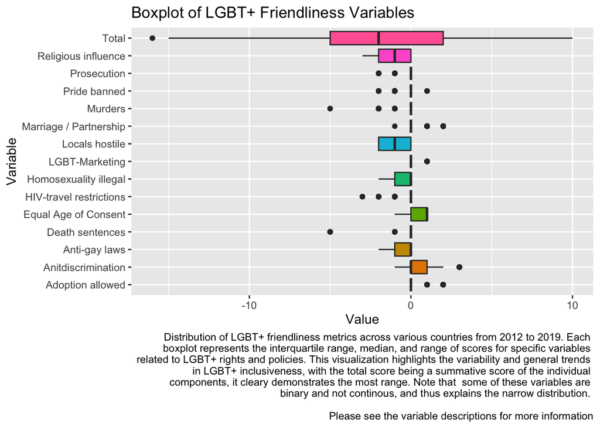

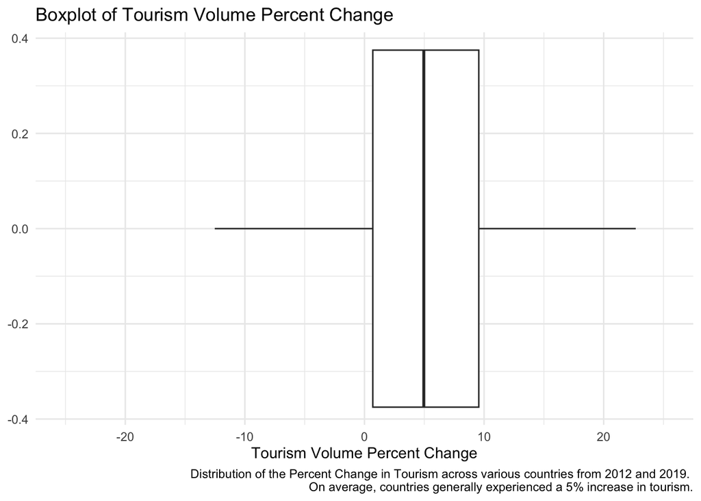

**Plot Combinding Both Tourism and LGBTQ friendliness**

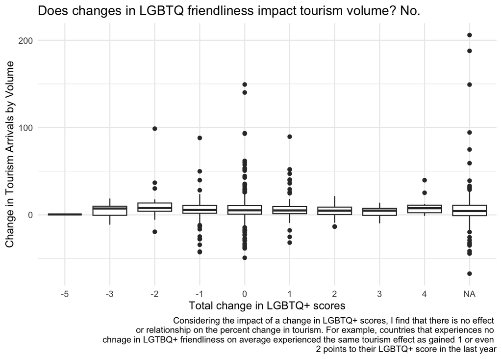

## Task 3: Research Design

**Main Regression Model:**

$$Percent\ Change\ Tourism\ Volume_i = \alpha + \beta_1( Change\ in\ LGBTQ\ Friendliness\ Variables)_{i1} + \epsilon_i$$

**Hypothesis:**

Do decreases in LGBTQ friendliness variables that hinder tourism in a given country result in a decrease in tourism volume to the country, as measured by percent change in the number of arrivals?

**Discussions of Covariates**

While in the above model, I do not use any potential covariates, the way I cleaned and prepared the data already takes into account one of the biggest potential covariates: size of country’s tourist volume. For example, common travel locations, such as Greece, are going to generally just have more travel, even against some similar sized or population sized countries. So its not as much controlling against just the population size, but by using percent change in tourist volume as the outcome, this adjusts for the normal level of travel to a given country more or less applying country fixed effects.

**Causal Relationship & Potential Unobserved Cofounders**

A significant challenge to the interpretabitiy of this model is the presence of unobserved confounders that could influence both LGBTQ+ policies and tourism volume, such as broader, economic conditions, political stability, or even year.  
For example, lets take a deeper look into political stability—often times political instability results in the claw back of demographic rights. Its entirely possible that far-right or other massive shifts in a countries government are both the cause of changes to LGBTQ friendliness and changes to the tourist volume.

Take another example, year, its possible that the year it is has an effect on LGBTQ friendliness score and then also year has an impact on tourism—for example, its possible that tourism for whatever reason just declined in 2013.

Another potential mechanism for influence not captured in the data is media coverage and awareness this hypothesis only works under the assumption that potential tourists are aware of the status of LGBTQ friendliness in a given country.

## Task 4: Empirical Extension

*I’m not 100% percent sure what exactly I want to use as the empirical extension (or multiple of them), so I just wanted to give you a few options and then I also booked time for us to chat on Friday to workshop it together.*

There are a variety of ways to help strengthen our conclusion, even if it is that there is no relationship between these variables. Below are some things that I could empoy, considering that my main model is listed above.

1. **New Index Variables:** Add an additional mode that instead of just total score as the independent variable, use all the sub components of the total. By doing this I could isolate to see if there is something specific that matters and not necessarily just the total score. In this I could also try many different combinations, where I hypothesize that these are the subcomponents that I think will have an impact on tourism and then use those or even create an index variable for it and then control it against the factors that I don’t think matter.
2. **Year Fixed Effects:** While my main model is already employing an effect simiar to fixed effects by doing country percent change, I could employ fixed effects for the year. For example, what if global tourism just declined in 2018? This then could help absorb some of those shocks. Not only could this help remove the effect of year, it also (partially) helps mediate concerns about global macroeconomic conditions that would impede or support increased tourism.
3. **Country Fixed Effects:** Implement country fixed effects in my regression models to control for all time-invariant unobserved heterogeneity between countries, which might influence both LGBTQ+ rights and tourism. This is also partially accounted for by %change but there could be other factors (for ex maybe this shows me that only particular regions is there an actual relationsip)
4. **Simplifying the model:** I could try to run a mode that predicts a just the direction of tourism change. Instead of having it be a continous variable I could make it just an binary variable that represents whether or not the country experienced an increase or a decrease in tourism.
5. **Regional Analysis**: Conduct separate analyses for different regions (e.g., Europe, Asia, Africa) to account for regional variations in cultural, economic, and political factors that could influence both LGBTQ+ rights and tourism independently.
6. **Economic Controls**: Include GDP per capita and economic growth rates in your model to control for the overall economic environment of the country, which could independently affect tourism volumes.
7. **Time-Lagged Variables**: I could use lagged values (1-2 years) of the LGBTQ+ friendliness measures to examine if changes in LGBTQ+ policies impact tourism with a time delay, which would help clarify direction (not that I am particularly concerned about tourism rates impacting LGBTQ+ friendliness)
8. **Difference-in-Differences**: I could empoy a difference-in-differences approach where I compare changes in tourism volumes in countries that improved on LGBTQ+ legislation against those that did not over the same period. The only issue is then I would have to pick a specific year and then that would reduce the models range. However this could help cover countries that were already improving/not improving at a steady rate.

## Task 5: Clean-up

Clean-up the document. If you haven’t, incorporate a Bibliography using a references.bib file and Quarto citations. Remove the printed warnings and code from your document. Create clear sections for each stage of the analysis. (20%)

**A note on AI**  
*I used GPT4 many times throughout this assignment. Noteably in helping me code in time saving measures (instead of calculating the percent change by hand for 12+ variables and over 9 times each) I got it to give me the code to do it automatically. Moreover, especially with the chaos that is pivoting I used it to help me ID rows using str type commands. I also used GPT4 to help with editing, debugging, trying to use python instead (did not go with in the end), as well as some editing/rephrasing and reworking of my explanations and responses. Moreover, I used it to help brainstorm some potential confounders (was okay at doing it) and then also used it to help brainstorm remedies (was meh at it).*